# PSYCH5020-Bartlett: Homework 03

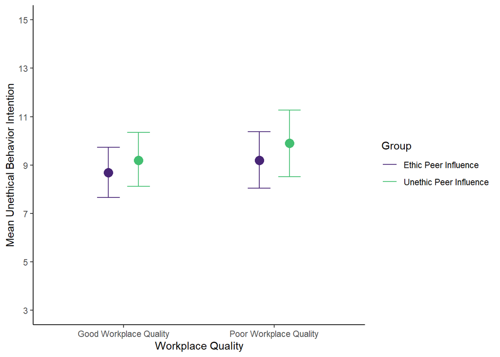

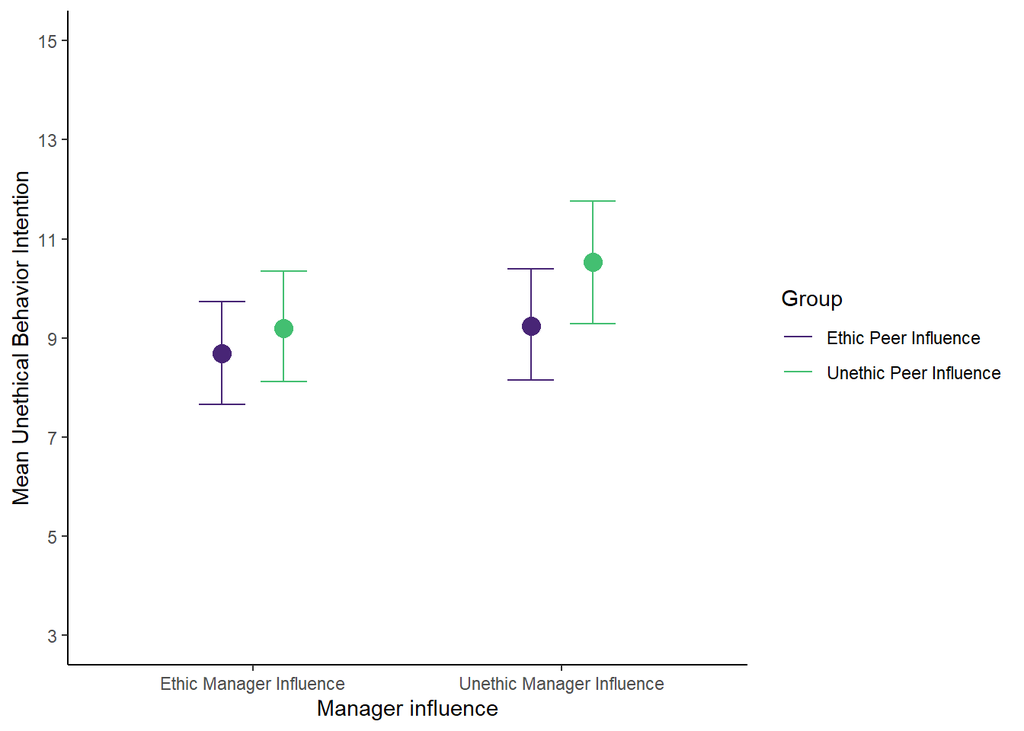

|  | R2 Estimate | Estimated Error | Lower 95% HDI | Upper 95% HDI |
| --- | --- | --- | --- | --- |
| Model with all the interaction | 0.10 | 0.04 | 0.03 | 0.19 |
| Model without interaction 4 | 0.09 | 0.04 | 0.02 | 0.18 |
| model without interaction 3 | 0.09 | 0.04 | 0.02 | 0.17 |
| model without interaction 2 | 0.10 | 0.04 | 0.03 | 0.19 |
| model without interaction 1 | 0.09 | 0.04 | 0.03 | 0.19 |
| model without interaction 34 | 0.08 | 0.04 | 0.02 | 0.16 |
| model without interaction 24 | 0.09 | 0.04 | 0.02 | 0.18 |
| model without interaction 23 | 0.09 | 0.04 | 0.02 | 0.18 |
| model without interaction 14 | 0.08 | 0.04 | 0.02 | 0.17 |
| model without interaction 13 | 0.08 | 0.04 | 0.02 | 0.16 |
| model without interaction 12 | 0.09 | 0.04 | 0.03 | 0.18 |
| model without interaction 234 | 0.07 | 0.03 | 0.01 | 0.15 |
| model without interaction 134 | 0.06 | 0.03 | 0.01 | 0.14 |
| model without interaction 124 | 0.08 | 0.04 | 0.02 | 0.16 |
| model without interaction 123 | 0.09 | 0.04 | 0.02 | 0.17 |
| model without interaction 1234 | 0.06 | 0.03 | 0.01 | 0.13 |

Additionally, since we used a very restrictive prior in the beginning, we examined the model with the default prior and a weaker prior. The order of the summaries presented below are for the current model, the model with the default prior, and the model with the weaker prior (intercept - normal distribution with a mean of 7 and standard deviation of 3; coefficients - normal distribution with a mean of 0 and standard deviation of 1.5; sigma - exponential distribution with a rate parameter of 0.75).

```r
describe_posterior(Evans_fit1)
```

```
## Summary of Posterior Distribution
##
## Parameter                                             | Median |        95% CI |     pd |          ROPE | % in ROPE |  Rhat |     ESS
## -------------------------------------------------------------------------------------------------------------------------------------
## (Intercept)                                           |   8.69 | [ 7.65, 9.74] |   100% | [-0.10, 0.10] |        0% | 1.000 | 5921.00
## workplace_quality1                                    |   0.49 | [-0.60, 1.59] | 81.38% | [-0.10, 0.10] |    10.21% | 1.000 | 6032.00
## manager_influence1                                    |   0.55 | [-0.53, 1.60] | 82.93% | [-0.10, 0.10] |    10.24% | 1.000 | 6470.00
## peer_influence1                                       |   0.50 | [-0.60, 1.59] | 82.33% | [-0.10, 0.10] |     9.71% | 0.999 | 6294.00
## workplace_quality1:manager_influence1                 |   0.49 | [-0.70, 1.72] | 78.42% | [-0.10, 0.10] |     9.61% | 1.000 | 6261.00
## workplace_quality1:peer_influence1                    |   0.19 | [-1.03, 1.42] | 61.60% | [-0.10, 0.10] |    12.79% | 0.999 | 5919.00
## manager_influence1:peer_influence1                    |   0.77 | [-0.40, 1.96] | 89.58% | [-0.10, 0.10] |     6.32% | 1.000 | 6148.00
## workplace_quality1:manager_influence1:peer_influence1 |   0.39 | [-0.96, 1.69] | 71.10% | [-0.10, 0.10] |    10.74% | 1.000 | 6561.00
```

```r
describe_posterior(Evans_fit2)
```

```
## Summary of Posterior Distribution
##
## Parameter                                             |    Median |        95% CI |     pd |          ROPE | % in ROPE |  Rhat |     ESS
## ----------------------------------------------------------------------------------------------------------------------------------------
## (Intercept)                                           |      7.91 | [ 6.01, 9.82] |   100% | [-0.10, 0.10] |        0% | 1.001 | 1909.00
## workplace_quality1                                    |      1.60 | [-0.98, 4.19] | 89.03% | [-0.10, 0.10] |     2.84% | 1.002 | 1763.00
## manager_influence1                                    |      0.94 | [-1.69, 3.59] | 75.67% | [-0.10, 0.10] |     4.84% | 1.001 | 1857.00
## peer_influence1                                       |      1.23 | [-1.48, 3.96] | 81.60% | [-0.10, 0.10] |     3.71% | 1.002 | 1627.00
## workplace_quality1:manager_influence1                 | -8.06e-04 | [-3.93, 3.66] | 50.00% | [-0.10, 0.10] |     4.45% | 1.002 | 1771.00
## workplace_quality1:peer_influence1                    |     -1.19 | [-5.21, 2.72] | 72.47% | [-0.10, 0.10] |     3.55% | 1.002 | 1629.00
## manager_influence1:peer_influence1                    |      1.04 | [-2.69, 4.90] | 71.62% | [-0.10, 0.10] |     3.79% | 1.002 | 1535.00
## workplace_quality1:manager_influence1:peer_influence1 |      1.28 | [-4.07, 6.91] | 67.07% | [-0.10, 0.10] |     2.92% | 1.002 | 1557.00
```

```r
describe_posterior(Evans_fit4)
```

```
## Summary of Posterior Distribution
##
## Parameter                                             | Median |        95% CI |     pd |          ROPE | % in ROPE |  Rhat |     ESS
## -------------------------------------------------------------------------------------------------------------------------------------
## (Intercept)                                           |   8.34 | [ 7.00, 9.65] |   100% | [-0.10, 0.10] |        0% | 1.000 | 3826.00
## workplace_quality1                                    |   0.85 | [-0.83, 2.43] | 84.92% | [-0.10, 0.10] |     6.29% | 1.000 | 3418.00
## manager_influence1                                    |   0.68 | [-0.89, 2.22] | 80.10% | [-0.10, 0.10] |     7.63% | 1.001 | 3678.00
## peer_influence1                                       |   0.74 | [-0.93, 2.30] | 80.83% | [-0.10, 0.10] |     6.79% | 1.000 | 3605.00
## workplace_quality1:manager_influence1                 |   0.53 | [-1.48, 2.55] | 70.50% | [-0.10, 0.10] |     7.55% | 1.000 | 3370.00
## workplace_quality1:peer_influence1                    |  -0.11 | [-2.09, 1.79] | 54.80% | [-0.10, 0.10] |     9.03% | 1.001 | 2950.00
## manager_influence1:peer_influence1                    |   1.11 | [-0.86, 3.04] | 86.75% | [-0.10, 0.10] |     4.58% | 1.001 | 3486.00
## workplace_quality1:manager_influence1:peer_influence1 |   0.48 | [-1.79, 2.69] | 64.90% | [-0.10, 0.10] |     6.74% | 1.000 | 3951.00
```

Upon examining the summary, it becomes apparent that in the default prior and weaker prior models, the coefficient of the interaction between workplace_quality1 and peer influence is negative, contrary to the direction in our current model. This finding suggests that the prior specifications we used may have been too restrictive. As a result, it may be necessary to revisit our prior assumptions and consider using a less stringent prior to enable a more nuanced analysis and interpretation of the results.

I had upload all the model and the data that i used to the github (link at every beginning), feel free to download and re-run it.

# Question 3: Replication of Dunn (2014)

The data file below includes an unpublished replication of [Dunn (2014)](http://link.springer.com/10.1007/s10755-013-9256-1). Dunn wanted to understand the impact of motivation and statistics anxiety on students’ academic procrastination. The sample in the original study included graduate students who were completing an online only course. The study included the following variables:

- General strategies for learning (GLS; `GLS`) - A subscale of the Motivated Strategies for Learning Questionnaire (MSLQ) which measures academic self-regulation. Measured on a 1-7 scale, with higher values meaning higher self-regulation.
- Intrinsic motivation (`Instrinsic`) - A subscale of the MSLQ which measure intrinsic motivation - where people inherently enjoy a task. Measured on a 1-7 scale, with higher values meaning higher intrinsic motivation.
- Statistical Anxiety Rating Scale (STARS; `STARS`) - A measure of statistics anxiety where we only included the statistics test and class anxiety subscale. Measured on a 1-5 scale, with higher values meaning higher statistics anxiety.
- Procrastination Assessment Scale for Students (PASS; `PASS`) - A measure of passive procrastination on keeping up with writing assignments and studying for exams. The scales includes six items measured on a 1-5 scale with higher scores meaning greater procrastination, but this scale uses the sum of items creating a possible range of 6-30.

Dunn used PASS as an outcome variable and used GLS, intrinsic motivation, and STARS as predictor variables. They used frequentist statistics and found the model explained a statistically significant amount of variance in PASS, and GLS was a significant negative predictor of PASS. For further information on the method and results, please see the linked references.

We wanted to replicate the study to see if we would observe similar findings in traditional face-to-face students. Our research question was: do instrinsic motivation, academic self-regulation, and statistics anxiety influence students’ passive procrastination? We expected intrinsic motivation and self-regulation to be negative predictors, whereas we expected statistics anxiety to be a positive predictor of passive procrastination.

We would like you to use what you learnt about Bayesian statistics to address the research question and predictions above. You can use any techniques covered in the lectures on Bayesian statistics to analyse the data in the way you think best addresses the research question. After walking through your analysis, write a short results section communicating your findings with appropriate statistics and data visualisation. Please justify your approach and make sure you include commented code.

```r
# read data from a replication attempt of Dunn (2014)
Dunn_data <- read_csv("Data/Dunn_replication.csv")

glimpse(Dunn_data)
```

```
## Rows: 140
## Columns: 17
## $ ...1           <dbl> 1, 2, 3, 4, 5, 6, 7, 8, 9, 10, 11, 12, 13, 14, 15, 16, …
## $ user_id        <dbl> 98468, 98469, 98471, 98474, 98488, 98489, 98502, 98504,…
## $ consent        <dbl> 1, 1, 1, 1, 1, 1, 1, 1, 1, 1, 1, 1, 1, 1, 1, 1, 1, 1, 1…
## $ age            <dbl> 18, 18, 18, 18, 18, 18, 32, 18, 18, 18, 18, 18, 19, 18,…
## $ gender         <dbl> 0, 0, 1, 1, 1, 1, 1, 0, 0, 1, 1, 0, 0, 2, 2, 1, 1, 1, 1…
## $ year_study     <dbl> 1, 1, 1, 1, 1, 1, 1, 1, 1, 1, 1, 1, 2, 1, 1, 1, 1, 1, 1…
## $ data_check     <dbl> 1, 1, 1, 1, 1, 1, 1, 1, 1, 1, 1, 1, 1, 1, 1, 1, 1, 1, 1…
## $ GSL_mean       <dbl> 3.8, 5.4, 3.4, 3.4, 2.6, 3.8, 2.2, 5.4, 3.2, 4.6, 4.8, …
## $ Intrinsic_mean <dbl> 4.25, 4.50, 4.50, 4.50, 4.50, 6.00, 3.75, 6.75, 3.25, 6…
## $ STARS_mean     <dbl> 3.000, 3.125, 4.750, 3.375, 3.625, 3.750, 3.875, 3.250,…
## $ PASS_sum       <dbl> 16, 18, 15, 22, 23, 24, 20, 15, 19, 14, 22, 27, 21, 18,…
## $ pass_1         <dbl> 3, 4, 4, 5, 5, 5, 4, 3, 4, 3, 4, 5, 4, 4, 3, 2, 3, 2, 5…
## $ pass_2         <dbl> 3, 3, 3, 4, 5, 2, 4, 3, 4, 2, 3, 4, 3, 4, 4, 1, 4, 3, 5…
## $ pass_3         <dbl> 4, 5, 3, 5, 5, 5, 5, 4, 5, 2, 5, 5, 3, 5, 5, 3, 5, 4, 3…
## $ pass_4         <dbl> 1, 1, 1, 2, 2, 4, 2, 2, 2, 1, 1, 5, 2, 1, 3, 3, 2, 2, 2…
## $ pass_5         <dbl> 2, 2, 1, 3, 3, 4, 2, 1, 1, 2, 5, 3, 5, 1, 3, 1, 1, 3, 3…
## $ pass_6         <dbl> 3, 3, 3, 3, 3, 4, 3, 2, 3, 4, 4, 5, 4, 3, 3, 3, 3, 4, 3…
```

## Data Analysis

The research question focuses on investigating whether intrinsic motivation, academic self-regulation, and statistics anxiety influence students’ passive procrastination, with specific attention to the variables GSL_mean, Intrinsic_mean, and STARS_mean in relation to PASS_sum. We expected intrinsic motivation (Intrinsic_mean) and self-regulation (GSL_mean) to be negative predictors, whereas we expected statistics anxiety (STARS_mean) to be a positive predictor of passive procrastination. Before delving into further analysis, it is necessary to mean center the predictors to mitigate potential multicollinearity issues, improve numerical stability, and enhance interpretability.

```r
Dunn_data <- Dunn_data %>%
  mutate(GSL_mean = GSL_mean - mean(GSL_mean),
         Intrinsic_mean = Intrinsic_mean - mean(Intrinsic_mean),
         STARS_mean = STARS_mean - mean(STARS_mean))
```

Previous research has employed multiple linear regression to investigate the influence of three independent variables on the dependent variable. These studies have thoroughly examined the independence, normality, homoscedasticity, and linearity of the dataset and have found that the assumptions for multiple linear regression are met. As a result, interactions were not included in the analysis, as the variables were treated as independent. However, in our current research, despite replicating previous studies, we will still incorporate interactions to thoroughly recheck the underlying assumptions of the dataset, given the small sample size in the previous research.

### Multiple Linear Regression Model

```r
Dunn_model <- bf(PASS_sum ~ GSL_mean * Intrinsic_mean * STARS_mean)
```

### Prior Decision

We also need to have a look at the defult prior first. To see which prior we allow to change. moreover, Drawing from my experience in question 2, I have decided to choose a weaker prior for this question in order to avoid potential hidden influences. By using a less restrictive prior, I aim to minimize the potential bias introduced by overly informative priors and obtain a more robust and unbiased analysis of the data.

```r
get_prior(Dunn_model, data = Dunn_data)
```

```
##                  prior     class                               coef group resp
##                 (flat)         b
##                 (flat)         b                           GSL_mean
##                 (flat)         b            GSL_mean:Intrinsic_mean
##                 (flat)         b GSL_mean:Intrinsic_mean:STARS_mean
##                 (flat)         b                GSL_mean:STARS_mean
##                 (flat)         b                     Intrinsic_mean
##                 (flat)         b          Intrinsic_mean:STARS_mean
##                 (flat)         b                         STARS_mean
##  student_t(3, 18, 4.4) Intercept
##   student_t(3, 0, 4.4)     sigma
##  dpar nlpar lb ub       source
##                        default
##                   (vectorized)
##                   (vectorized)
##                   (vectorized)
##                   (vectorized)
##                   (vectorized)
##                   (vectorized)
##                   (vectorized)
##                        default
##              0         default
```

Based on the previous research (Dunn, 2014), we can select our prior for the intercept. The estimated intercept of PASS is 15.29 with a standard deviation of 5.26. Although there is no information available about the range or confidence interval of previous PASS results, we do know that the possible range of the scale is 6-30. Therefore, we choose a normal distribution intercept prior with a mean of 15 and a standard deviation of 5, allowing us to cover the entire scale and aligning with the findings of previous research. The prior distribution for the intercept is visualized below. The choice of a normal distribution is appropriate here, as previous research has examined the normality of the data.

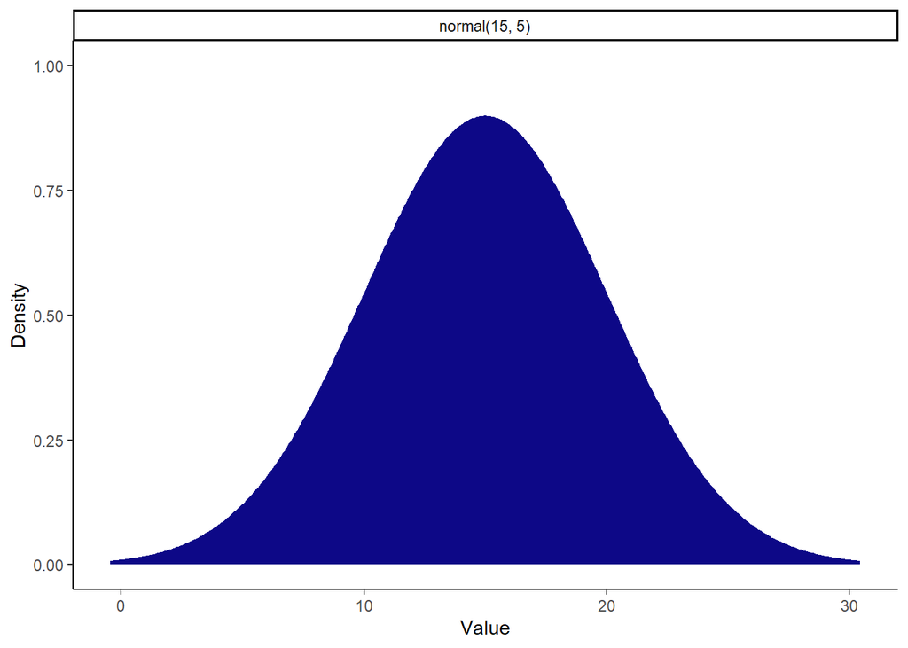

```r
Dunn_intercptpriors <- c(prior(normal(15, 5)))

Dunn_intercptpriors %>%
   parse_dist()%>%
   ggplot(aes(y = 0, dist = .dist, args = .args, fill = prior)) +
   stat_slab(normalize = "panels") +
   scale_fill_viridis_d(option = "plasma", end = 0.9) +
   guides(fill = "none") +
   facet_wrap(~prior) +
   labs(x = "Value", y = "Density") +
   theme_classic()
```

For the coefficients, we have information from previous research on the unstandardized β weights and partial correlations. The β coefficient for GSL is -2.5, for STCA it is 0.78, and for IGO it is -0.67. These coefficients represent the change in the outcome variable Y associated with a change of 1 unit in the corresponding independent variable. Based on this information, I have established the prior distribution as normal(0, 1.25) for the coefficients. This prior has a peak at 0, but the standard deviation is larger (1.25), allowing for a larger probability of accepting larger values in both directions, considering that one of our β coefficients (-2.5) is quite large. This prior distribution is visualized below.

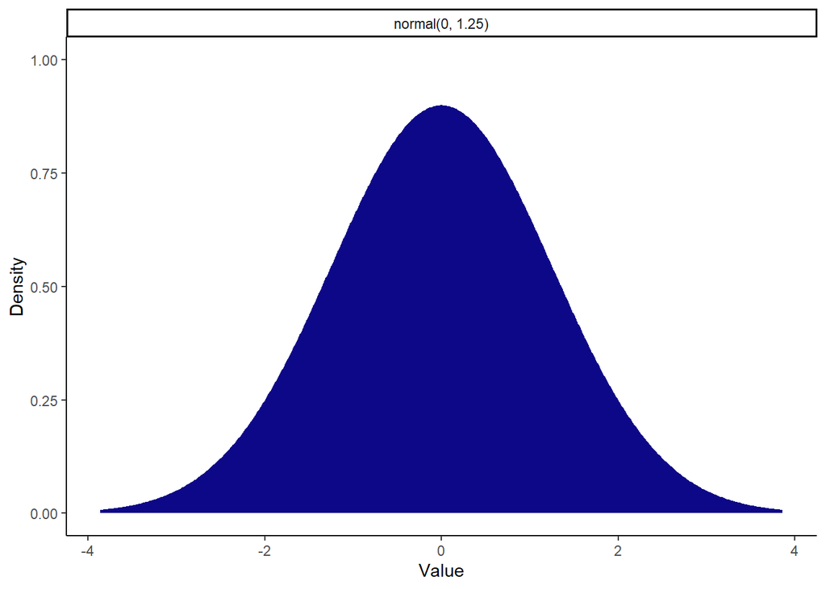

```r
Dunn_bpriors <- c(prior(normal(0,1.25)))

Dunn_bpriors %>%
  parse_dist()%>%
  ggplot(aes(y = 0, dist = .dist, args = .args, fill = prior)) +
  stat_slab(normalize = "panels") +
  scale_fill_viridis_d(option = "plasma", end = 0.9) +
  guides(fill = "none") +
   facet_wrap(~prior) +
  labs(x = "Value", y = "Density") +
  theme_classic()
```

Based on the reported standard deviation (SD) of 5.26 for the estimated intercept in previous research, we can incorporate a more informative prior for sigma. To capture the possibility of a wider range of values for sigma, given our expectation that it need to be larger enough to cover the SD found in the previous study, I suggest using an exponential(0.5) distribution. This distribution is commonly used for SD, with the density centered around zero and gradually decreasing as values become more positive. The prior distribution for sigma is visualized below, reflecting our updated understanding.

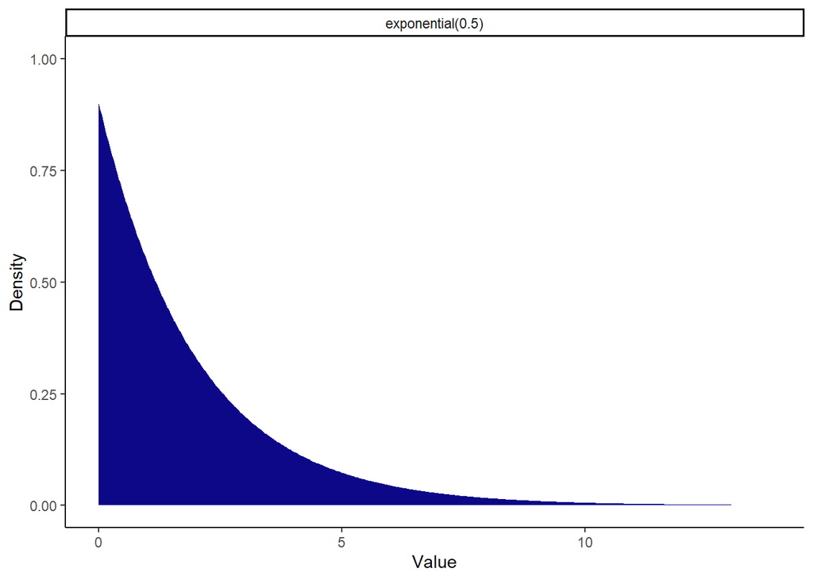

```r
Dunn_sigmapriors <- c(prior(exponential(0.5)))

Dunn_sigmapriors %>%
  parse_dist()%>%
  ggplot(aes(y = 0, dist = .dist, args = .args, fill = prior)) +
  stat_slab(normalize = "panels") +
  scale_fill_viridis_d(option = "plasma", end = 0.9) +
  guides(fill = "none") +
   facet_wrap(~prior) +
  labs(x = "Value", y = "Density") +
  theme_classic()
```

### Model Fitting

Once the prior distributions for the model parameters have been established, the next step is to define and save these priors as objects. These objects will be used to update the priors with the current dataset and obtain posterior distributions using Bayesian updating. moreover, although we not know about the current model yet.

```r
Dunn_priors <- set_prior("normal(0,1.25)", class = "b") +
  set_prior("normal(15, 5)", class = "Intercept") +
  set_prior("exponential(0.5)", class = "sigma")

Dunn_fit1 <- brm(
  formula = Dunn_model,
  data = Dunn_data,
  family = gaussian(),
  prior = Dunn_priors,
  seed = 200323,
  sample_prior = TRUE,
  file = "Models/Dunn_model1"
)
```

### Model Checking

Similar to question 2, i will start with model checking of R hat and ESS and visualized the the Markov Chain Monte Carlo (MCMC) sampling process.

```r
summary(Dunn_fit1)
```

```
##  Family: gaussian
##   Links: mu = identity; sigma = identity
## Formula: PASS_sum ~ GSL_mean * Intrinsic_mean * STARS_mean
##    Data: Dunn_data (Number of observations: 140)
##   Draws: 4 chains, each with iter = 2000; warmup = 1000; thin = 1;
##          total post-warmup draws = 4000
##
## Population-Level Effects:
##                                    Estimate Est.Error l-95% CI u-95% CI Rhat
## Intercept                             18.91      0.33    18.24    19.56 1.00
## GSL_mean                              -2.35      0.39    -3.12    -1.57 1.00
## Intrinsic_mean                         0.77      0.33     0.11     1.43 1.00
## STARS_mean                             0.25      0.44    -0.63     1.14 1.00
## GSL_mean:Intrinsic_mean                0.18      0.26    -0.34     0.70 1.00
## GSL_mean:STARS_mean                    0.10      0.50    -0.88     1.08 1.00
## Intrinsic_mean:STARS_mean             -0.32      0.40    -1.13     0.46 1.00
## GSL_mean:Intrinsic_mean:STARS_mean    -0.08      0.35    -0.77     0.60 1.00
##                                    Bulk_ESS Tail_ESS
## Intercept                              6688     2878
## GSL_mean                               4537     3520
## Intrinsic_mean                         4839     3216
## STARS_mean                             5039     2995
## GSL_mean:Intrinsic_mean                5800     2446
## GSL_mean:STARS_mean                    4449     3510
## Intrinsic_mean:STARS_mean              4171     3311
## GSL_mean:Intrinsic_mean:STARS_mean     5470     3515
##
## Family Specific Parameters:
##       Estimate Est.Error l-95% CI u-95% CI Rhat Bulk_ESS Tail_ESS
## sigma     3.53      0.21     3.14     3.96 1.00     6080     2795
##
## Draws were sampled using sampling(NUTS). For each parameter, Bulk_ESS
## and Tail_ESS are effective sample size measures, and Rhat is the potential
## scale reduction factor on split chains (at convergence, Rhat = 1).
```

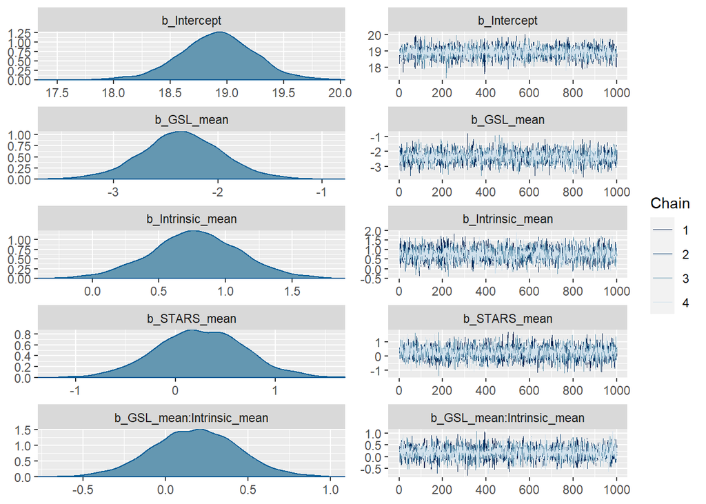

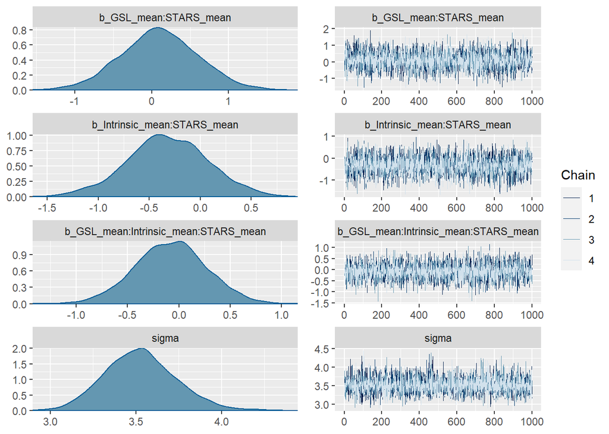

```r
plot(Dunn_fit1)
```

As part of model checking, I examined the R hat statistic and effective sample size (ESS) for the MCMC sampling process, similar to question 2. The R hat statistic was found to be equal to 1, and the ESS exceeded 1000, indicating that the sampling process is reliable and there are no issues with chain convergence. Moreover, visual inspection of the MCMC chains revealed that they are well mixed and no signs of being trapped at a single value or displaying excessive movement in one direction. This three result supports the reliability of the MCMC sampling process and reinforce the validity of the posterior distributions obtained.

The next step is to evaluate whether the current model aligns with the observed data pattern and see if the model captures the observed trends, patterns, and variability in the data.

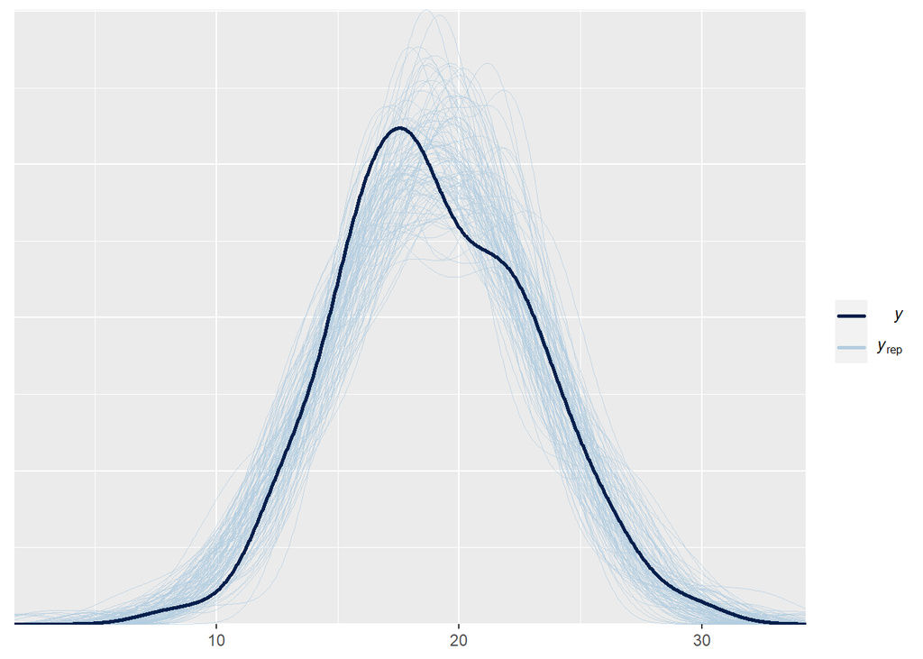

```r
pp_check(Dunn_fit1,
         ndraws = 100)
```

Based on the current coefficients, we can conclude that our findings regarding self-regulation (GLS) and statistics anxiety are consistent with our expectations. However, our finding of intrinsic motivation is inconsistent with our expectation, as the coefficients suggest a different direction of effect than anticipated.

### Point Estimate of Model

Based on the summery, the point estimates for the population-level effects are as follows:

- Intercept: 18.91 [18.24, 19.56]
- GSL_mean: -2.35 [-3.12, -1.57]
- Intrinsic_mean: 0.77 [0.11, 1.43]
- STARS_mean: 0.25 [-0.63, 1.14]
- Interaction between GSL_mean and Intrinsic_mean: 0.18 [-0.34, 0.70]
- Interaction between GSL_mean and STARS_mean: 0.10 [-0.88, 1.08]
- Interaction between Intrinsic_mean and STARS_mean: -0.32 [-1.13, 0.46]
- Interaction between GSL_mean, Intrinsic_mean and STARS_mean: -0.08 [-0.77, 0.60]

The interpretation of these coefficients is as follows:

- The coefficient for GLS_mean indicates that, change of 1 unit in the GSL score is associated with a change of -2.35 units in the PASS score from the intercept estimate.
- The coefficient for Intrinsic_mean indicates that, change of 1 unit in the intrinsic motivation score is associated with a change of 0.77 units in the PASS score from the intercept estimate.
- The coefficient for STARS_mean indicates that, change of 1 unit in the Statistical Anxiety Rating Scale score is associated with a change of 0.25 units in the PASS score from the intercept estimate.
- The coefficient for Interaction between GSL_mean and Intrinsic_mean indicates that, on average, PASS score increases by 0.18 due to this interaction.
- The coefficient for Interaction between GSL_mean and STARS_mean indicates that, on average, PASS score increases by 0.10 due to this interaction. .
- The coefficient for Interaction between Intrinsic_mean and STARS_mean indicates that, on average, PASS score decreases by 0.32 due to this interaction.
- The coefficient for Interaction between GSL_mean, Intrinsic_mean and STARS_mean indicates that, on average, PASS score decreases by 0.08 due to this interaction.

Based on current coefficients, we can conclude that our finding of self-regulation (GLS) and statistics anxiety are consistant with our expectation. but our finding of intrinsic motivation is inconsistant with our expectation.

### Posterior Distribution

Similar to question 2, I will begin by visualizing the probability of direction with the priors.

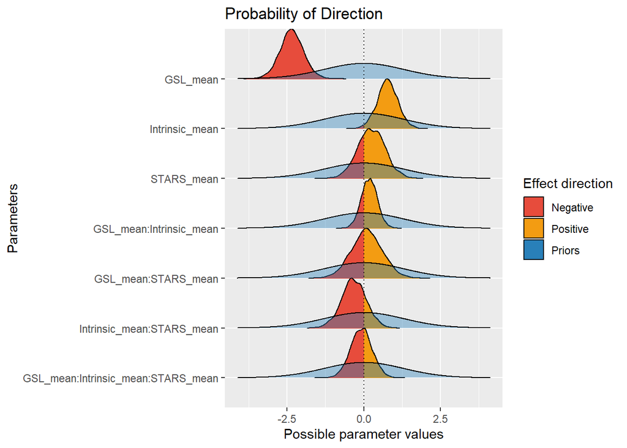

```r
plot(p_direction(Dunn_fit1),
     priors = TRUE)
```

Based on the plot, it can be observed that for the variable GLS, all of the posterior distribution is below zero, while for intrinsic motivation, almost all of the posterior distribution is above zero. However, for the other variables, there seems to be no discernible effect, although further evaluation is needed. To gain a better understanding, I also plotted the Highest Density Intervals (HDI) to further examine the credible ranges of the estimated parameters.

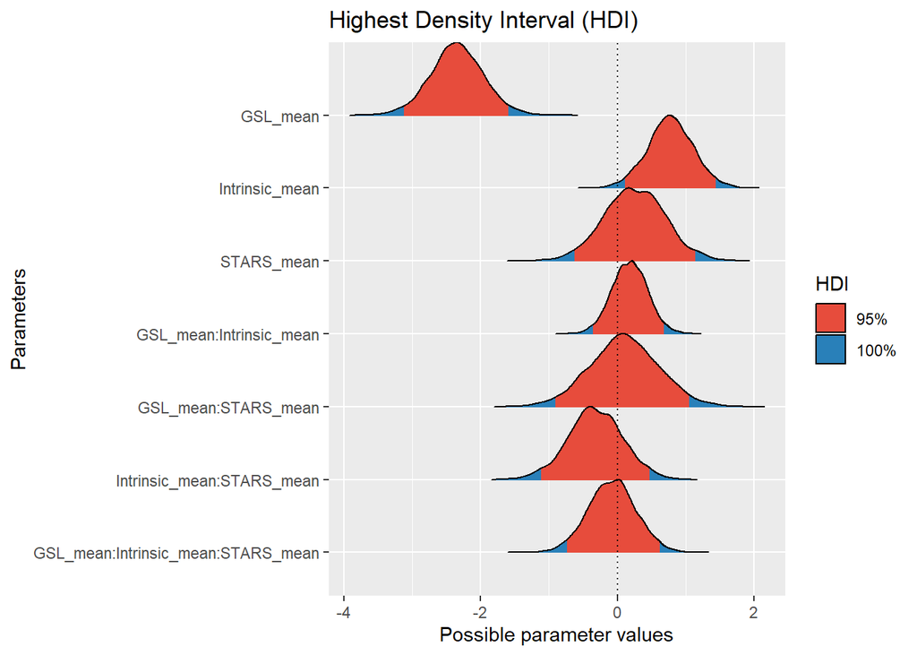

```r
plot(bayestestR::hdi(Dunn_fit1))
```

Based on the HDI plot, we can draw a similar conclusion as the probability of direction plot. The Highest Density Intervals (HDI) for the variables GLS and intrinsic motivation do not include zero, indicating that there is a high probability that GLS has a negative effect and intrinsic motivation has a positive effect. However, for the current dataset, we can only draw conclusions for these two variables. If we want to draw more conclusions of other variables based on the plot, we need to collect more data.

Furthermore, based on the analysis of the probability of direction plot and the HDI plot, it has been further revealed that the effect of intrinsic motivation is opposite to our initial expectation, showing a positive effect instead of a negative one. On the other hand, the effect of General Strategies for Learning (GLS) aligns with our expectation. As for statistics anxiety, while the plot shows a positive direction, the effect does not seem significant. Therefore, it is crucial to perform hypothesis testing to gain a deeper understanding of the dataset and obtain more conclusive insights.

### Hypothesis Testing

Based on the research question: do instrinsic motivation, academic self-regulation, and statistics anxiety influence students’ passive procrastination? We expected intrinsic motivation and self-regulation to be negative predictors, whereas we expected statistics anxiety to be a positive predictor of passive procrastination. I have outlined the following one tail hypotheses based on our expectations for H1,2,3.

- H1 Alternative: Self-regulation will have an negative effect on passive procrastination.
- H1 null: Self-regulation will have an possitive effect on passive procrastination.
- H2 Alternative: Intrinsic motivation will have an negative effect on passive procrastination.
- H2 null: Intrinsic motivation will have an possitive effect on passive procrastination.
- H3 Alternative: Statistics anxiety will have an positive effect on passive procrastination.
- H3 null: Statistics anxiety will have an nagetive effect on passive procrastination.

As for the interactions, since they are of personal interest, we do not set a specific direction for the hypotheses and are interested in exploring whether there are any significant effects of each interaction on the outcome，therefore the hypothesis will be in two tails.

- H4 Alternative: Interaction between GSL_mean and Intrinsic_mean will affect passive procrastination.
- H4 null: Interaction between GSL_mean and Intrinsic_mean will not affect passive procrastination.
- H5 Alternative: Interaction between GSL_mean and STARS_mean will affect passive procrastination.
- H5 null: Interaction between GSL_mean and STARS_mean will not affect passive procrastination.
- H6 Alternative: Interaction between Intrinsic_mean and STARS_mean will affect passive procrastination.
- H6 null: Interaction between Intrinsic_mean and STARS_mean will not affect passive procrastination.
- H7 Alternative: Interaction between GSL_mean, Intrinsic_mean and STARS_mean will affect passive procrastination.
- H7 null: Interaction between GSL_mean, Intrinsic_mean and STARS_mean will not affect passive procrastination.

We still use hypothesis() function to exam the hypothesis.

```r
(DBFh01 <- hypothesis(Dunn_fit1,
           hypothesis = "GSL_mean > 0"))
```

```
## Hypothesis Tests for class b:
##       Hypothesis Estimate Est.Error CI.Lower CI.Upper Evid.Ratio Post.Prob Star
## 1 (GSL_mean) > 0    -2.35      0.39    -2.98    -1.71          0         0
## ---
## 'CI': 90%-CI for one-sided and 95%-CI for two-sided hypotheses.
## '*': For one-sided hypotheses, the posterior probability exceeds 95%;
## for two-sided hypotheses, the value tested against lies outside the 95%-CI.
## Posterior probabilities of point hypotheses assume equal prior probabilities.
```

```r
(DBFh02 <- hypothesis(Dunn_fit1,
            hypothesis = "Intrinsic_mean > 0"))
```

```
## Hypothesis Tests for class b:
##             Hypothesis Estimate Est.Error CI.Lower CI.Upper Evid.Ratio
## 1 (Intrinsic_mean) > 0     0.77      0.33     0.21     1.32      77.43
##   Post.Prob Star
## 1      0.99    *
## ---
## 'CI': 90%-CI for one-sided and 95%-CI for two-sided hypotheses.
## '*': For one-sided hypotheses, the posterior probability exceeds 95%;
## for two-sided hypotheses, the value tested against lies outside the 95%-CI.
## Posterior probabilities of point hypotheses assume equal prior probabilities.
```

```r
(DBFh03 <- hypothesis(Dunn_fit1,
            hypothesis = "STARS_mean < 0"))
```

```
## Hypothesis Tests for class b:
##         Hypothesis Estimate Est.Error CI.Lower CI.Upper Evid.Ratio Post.Prob
## 1 (STARS_mean) < 0     0.25      0.44    -0.49     0.97        0.4      0.29
##   Star
## 1
## ---
## 'CI': 90%-CI for one-sided and 95%-CI for two-sided hypotheses.
## '*': For one-sided hypotheses, the posterior probability exceeds 95%;
## for two-sided hypotheses, the value tested against lies outside the 95%-CI.
## Posterior probabilities of point hypotheses assume equal prior probabilities.
```

```r
(DBFh04 <- hypothesis(Dunn_fit1,
            hypothesis = "GSL_mean:Intrinsic_mean = 0"))
```

```
## Hypothesis Tests for class b:
##                 Hypothesis Estimate Est.Error CI.Lower CI.Upper Evid.Ratio
## 1 (GSL_mean:Intrins... = 0     0.18      0.26    -0.34      0.7       3.57
##   Post.Prob Star
## 1      0.78
## ---
## 'CI': 90%-CI for one-sided and 95%-CI for two-sided hypotheses.
## '*': For one-sided hypotheses, the posterior probability exceeds 95%;
## for two-sided hypotheses, the value tested against lies outside the 95%-CI.
## Posterior probabilities of point hypotheses assume equal prior probabilities.
```

```r
(DBFh05 <- hypothesis(Dunn_fit1,
            hypothesis = "GSL_mean:STARS_mean = 0"))
```

```
## Hypothesis Tests for class b:
##                 Hypothesis Estimate Est.Error CI.Lower CI.Upper Evid.Ratio
## 1 (GSL_mean:STARS_m... = 0      0.1       0.5    -0.88     1.08       2.41
##   Post.Prob Star
## 1      0.71
## ---
## 'CI': 90%-CI for one-sided and 95%-CI for two-sided hypotheses.
## '*': For one-sided hypotheses, the posterior probability exceeds 95%;
## for two-sided hypotheses, the value tested against lies outside the 95%-CI.
## Posterior probabilities of point hypotheses assume equal prior probabilities.
```

```r
(DBFh06 <- hypothesis(Dunn_fit1,
            hypothesis = "Intrinsic_mean:STARS_mean = 0"))
```

```
## Hypothesis Tests for class b:
##                 Hypothesis Estimate Est.Error CI.Lower CI.Upper Evid.Ratio
## 1 (Intrinsic_mean:S... = 0    -0.32       0.4    -1.13     0.46       2.15
##   Post.Prob Star
## 1      0.68
## ---
## 'CI': 90%-CI for one-sided and 95%-CI for two-sided hypotheses.
## '*': For one-sided hypotheses, the posterior probability exceeds 95%;
## for two-sided hypotheses, the value tested against lies outside the 95%-CI.
## Posterior probabilities of point hypotheses assume equal prior probabilities.
```

```r
(DBFh07 <- hypothesis(Dunn_fit1,
            hypothesis = "GSL_mean:Intrinsic_mean:STARS_mean = 0"))
```

```
## Hypothesis Tests for class b:
##                 Hypothesis Estimate Est.Error CI.Lower CI.Upper Evid.Ratio
## 1 (GSL_mean:Intrins... = 0    -0.08      0.35    -0.77      0.6       3.38
##   Post.Prob Star
## 1      0.77
## ---
## 'CI': 90%-CI for one-sided and 95%-CI for two-sided hypotheses.
## '*': For one-sided hypotheses, the posterior probability exceeds 95%;
## for two-sided hypotheses, the value tested against lies outside the 95%-CI.
## Posterior probabilities of point hypotheses assume equal prior probabilities.
```

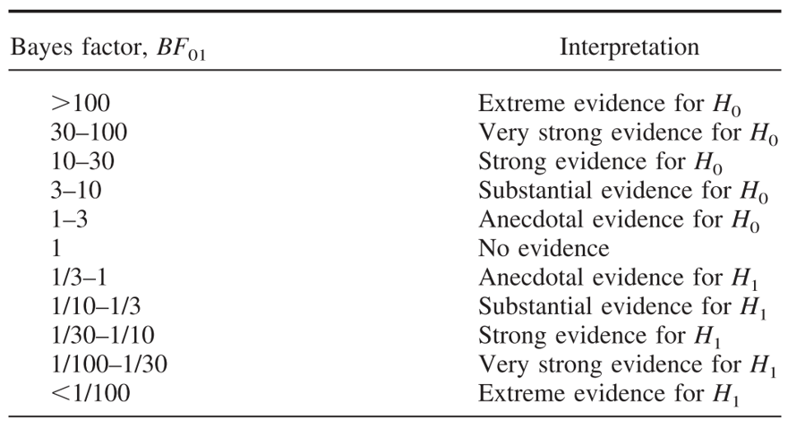

```r
 knitr::include_graphics("BH01.png")
```

We followed the instructions from Wagenmakers et al. (2011) to interpret our results. For H1, the evidence ratio is 0, indicating extreme evidence in favor of the hypothesis that Self-regulation will have an negative effect on passive procrastination. For H2, the evidence ratio is 77.4313725, which suggests very strong evidence in favor of the hypothesis that Intrinsic motivation will have an positive effect on passive procrastination. For H3, although we did not observe a significant effect based on the plot, there is anecdotal evidence (ER = 0.4020329) supporting the hypothesis that statistics anxiety has a positive effect on passive procrastination.

As for H4, H5, H6, and H7, which are the hypotheses about the interactions, all the evidence ratios are greater than 1, indicating that the evidence supports H0 (no interaction), which is consistent with previous research.

### Conditional Effect

Although we not interested in the interaction anymore, we can still have a look at the conditional effect to see how each variables affect the passive procrastination.

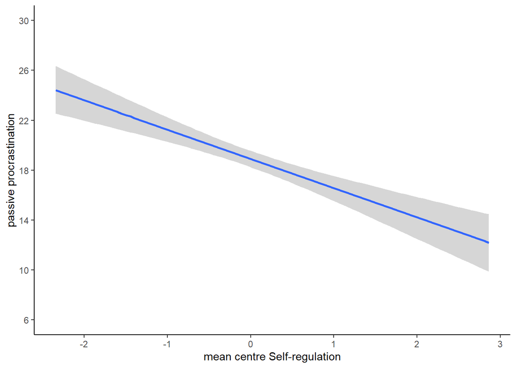

```r
Self_regulation_plot <- conditional_effects(Dunn_fit1,
                    effects = "GSL_mean")

plot(Self_regulation_plot,
     plot = FALSE)[[1]] +
  theme_classic() +
  scale_y_continuous(limits = c(6, 30), breaks = seq(6, 30, 4)) +
  labs(x = "mean centre Self-regulation", y = "passive procrastination")
```

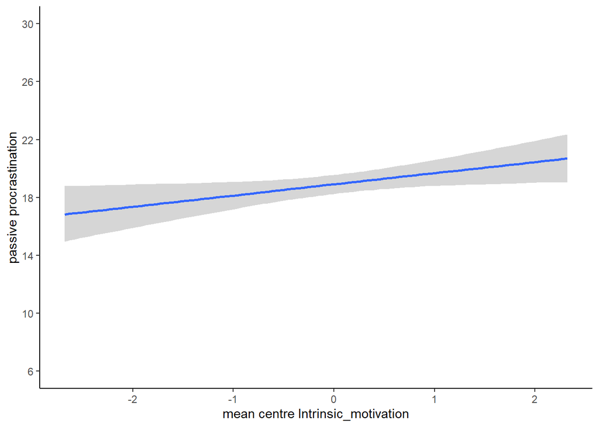

```r
Intrinsic_motivation_plot <- conditional_effects(Dunn_fit1,
                    effects = "Intrinsic_mean")

plot(Intrinsic_motivation_plot,
     plot = FALSE)[[1]] +
  theme_classic() +
  scale_y_continuous(limits = c(6, 30), breaks = seq(6, 30, 4)) +
  labs(x = "mean centre Intrinsic_motivation", y = "passive procrastination")
```

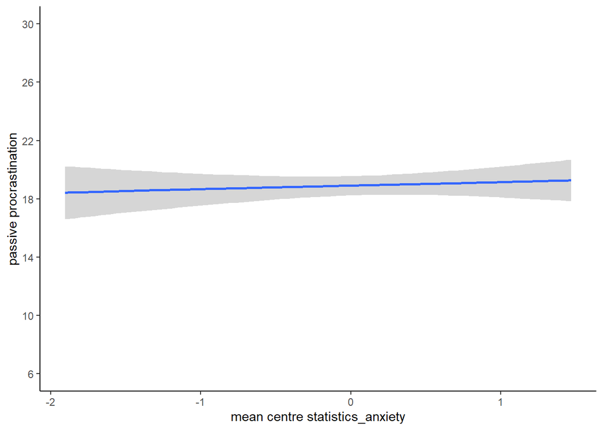

```r
statistics_anxiety_plot <- conditional_effects(Dunn_fit1,
                    effects = "STARS_mean")

plot(statistics_anxiety_plot,
     plot = FALSE)[[1]] +
  theme_classic() +
  scale_y_continuous(limits = c(6, 30), breaks = seq(6, 30, 4)) +
  labs(x = "mean centre statistics_anxiety", y = "passive procrastination")
```

### Model Sensitivity

In the final step of our analysis, we examined whether removing the interaction from the model would improve the R square value. Additionally, we investigated the sensitivity of the current model to the choice of prior specifications.

```r
Dunn_model2 <- bf(PASS_sum ~ GSL_mean+Intrinsic_mean+STARS_mean)
Dunn_fit2 <- brm(
  formula = Dunn_model2,
  data = Dunn_data,
  family = gaussian(),
  prior = Dunn_priors,
  seed = 200323,
  sample_prior = TRUE,
  file = "Models/Dunn_model2"
)
```

```r
R2_Dunn_fit1 <- as.data.frame(bayes_R2(Dunn_fit1))
R2_Dunn_fit2 <- as.data.frame(bayes_R2(Dunn_fit2))

R2_Dunn_table <- bind_rows(R2_Dunn_fit1, R2_Dunn_fit2)
rownames(R2_Dunn_table) <- c("Model with interaction", "Model without interaction")

knitr::kable(R2_Dunn_table,
             digits = 2,
             row.names = TRUE,
             col.names = c("R2 Estimate", "Estimated Error", "Lower 95% HDI", "Upper 95% HDI"))
```

|  | R2 Estimate | Estimated Error | Lower 95% HDI | Upper 95% HDI |
| --- | --- | --- | --- | --- |
| Model with interaction | 0.25 | 0.05 | 0.15 | 0.35 |
| Model without interaction | 0.23 | 0.05 | 0.13 | 0.33 |

Interestingly, despite our previous finding suggesting that interactions have no effect on passive procrastination, we observed that the model with interactions included had a slightly higher R-square compared to the model without interactions, although the difference was not substantial. We then proceeded to investigate the sensitivity of the current model to the choice of prior specifications by changing the user prior to the default prior, and examining its influence on the results.

```r
Dunn_fit3 <- brm(
  formula = Dunn_model,
  data = Dunn_data,
  family = gaussian(),
  seed = 200323,
  sample_prior = TRUE,
  file = "Models/Dunn_model3"
)
```

```r
describe_posterior(Dunn_fit1)
```

```
## Summary of Posterior Distribution
##
## Parameter                          | Median |         95% CI |     pd |          ROPE | % in ROPE |  Rhat |     ESS
## -------------------------------------------------------------------------------------------------------------------
## (Intercept)                        |  18.92 | [18.24, 19.56] |   100% | [-0.10, 0.10] |        0% | 1.000 | 6481.00
## GSL_mean                           |  -2.35 | [-3.12, -1.57] |   100% | [-0.10, 0.10] |        0% | 1.000 | 4532.00
## Intrinsic_mean                     |   0.77 | [ 0.11,  1.43] | 98.72% | [-0.10, 0.10] |        0% | 1.000 | 4787.00
## STARS_mean                         |   0.24 | [-0.63,  1.14] | 71.33% | [-0.10, 0.10] |    16.29% | 1.000 | 4903.00
## GSL_mean:Intrinsic_mean            |   0.18 | [-0.34,  0.70] | 75.75% | [-0.10, 0.10] |    25.92% | 1.000 | 5636.00
## GSL_mean:STARS_mean                |   0.10 | [-0.88,  1.08] | 57.80% | [-0.10, 0.10] |    17.39% | 0.999 | 4373.00
## Intrinsic_mean:STARS_mean          |  -0.33 | [-1.13,  0.46] | 79.42% | [-0.10, 0.10] |    14.87% | 1.000 | 4111.00
## GSL_mean:Intrinsic_mean:STARS_mean |  -0.08 | [-0.77,  0.60] | 58.40% | [-0.10, 0.10] |    23.89% | 0.999 | 5341.00
```

```r
describe_posterior(Dunn_fit3)
```

```
## Summary of Posterior Distribution
##
## Parameter                          | Median |         95% CI |     pd |          ROPE | % in ROPE |  Rhat |     ESS
## -------------------------------------------------------------------------------------------------------------------
## (Intercept)                        |  18.90 | [18.23, 19.56] |   100% | [-0.10, 0.10] |        0% | 1.000 | 5945.00
## GSL_mean                           |  -2.65 | [-3.44, -1.85] |   100% | [-0.10, 0.10] |        0% | 1.001 | 4201.00
## Intrinsic_mean                     |   0.97 | [ 0.27,  1.64] | 99.50% | [-0.10, 0.10] |        0% | 1.001 | 4027.00
## STARS_mean                         |   0.25 | [-0.67,  1.21] | 70.67% | [-0.10, 0.10] |    14.63% | 1.001 | 3963.00
## GSL_mean:Intrinsic_mean            |   0.21 | [-0.33,  0.72] | 78.15% | [-0.10, 0.10] |    24.55% | 1.000 | 5548.00
## GSL_mean:STARS_mean                |   0.27 | [-0.84,  1.35] | 68.70% | [-0.10, 0.10] |    13.11% | 1.000 | 3795.00
## Intrinsic_mean:STARS_mean          |  -0.39 | [-1.28,  0.45] | 81.90% | [-0.10, 0.10] |    13.47% | 1.001 | 3532.00
## GSL_mean:Intrinsic_mean:STARS_mean |  -0.09 | [-0.82,  0.65] | 59.52% | [-0.10, 0.10] |    21.95% | 1.002 | 3583.00
```

By comparing the short posterior summery, we can observed that the prior we choose has every little influence toward the final result. This suggests our results are robust to these two choices of prior and my choice prior is not too restrict in this question.

## Write up

The objective of this study is to investigate the influence of intrinsic motivation, academic self-regulation, and statistics anxiety on students’ passive procrastination. Dunn (2014) used GLS (self-regulation), intrinsic motivation, and STARS (statistics anxiety) as predictor variables and PASS (passive procrastination) as the outcome variable to examine their effects on passive procrastination. Dunn found that the effect of GLS on passive procrastination was significant. We aim to replicate Dunn’s research with face-to-face students and explore if we can identify any new findings. Despite the assumption of independence, normality, and homoscedasticity for the variables, we will include interactions in our model to investigate any possible effects of interactions.

We have developed a set of hypotheses for our study, with the first three having a specific direction, indicating our expectation for them, and requiring a one-tailed analysis. The remaining hypothesis is of personal interest, and thus, we will test it with a two-tailed analysis.

- H1 Alternative: Academic self-regulation will have a negative effect on passive procrastination.
- H1 Null: Academic self-regulation will have no effect on passive procrastination.
- H2 Alternative: Intrinsic motivation will have a negative effect on passive procrastination.
- H2 Null: Intrinsic motivation will have no effect on passive procrastination.
- H3 Alternative: Statistics anxiety will have a positive effect on passive procrastination.
- H3 Null: Statistics anxiety will have no effect on passive procrastination.
- H4 Alternative: The interaction between academic self-regulation (GSL_mean) and intrinsic motivation (Intrinsic_mean) will affect passive procrastination.
- H4 Null: The interaction between academic self-regulation (GSL_mean) and intrinsic motivation (Intrinsic_mean) will have no effect on passive procrastination.
- H5 Alternative: The interaction between academic self-regulation (GSL_mean) and statistics anxiety (STARS_mean) will affect passive procrastination.
- H5 Null: The interaction between academic self-regulation (GSL_mean) and statistics anxiety (STARS_mean) will have no effect on passive procrastination.
- H6 Alternative: The interaction between intrinsic motivation (Intrinsic_mean) and statistics anxiety (STARS_mean) will affect passive procrastination.
- H6 Null: The interaction between intrinsic motivation (Intrinsic_mean) and statistics anxiety (STARS_mean) will have no effect on passive procrastination.
- H7 Alternative: The interaction between academic self-regulation (GSL_mean), intrinsic motivation (Intrinsic_mean), and statistics anxiety (STARS_mean) will affect passive procrastination.
- H7 Null: The interaction between academic self-regulation (GSL_mean), intrinsic motivation (Intrinsic_mean), and statistics anxiety (STARS_mean) will have no effect on passive procrastination.

The prior distributions for the model parameters were chosen based on Dunn’s (2014) findings. The intercept was assigned a normal distribution with a mean of 15 and a standard deviation of 5, while the coefficients were assigned a normal distribution with a mean of 0 and a standard deviation of 1.25. The standard deviation parameter, sigma, was assigned an exponential distribution with a rate parameter of 0.5. A full report detailing the justification for these priors is available upon request.

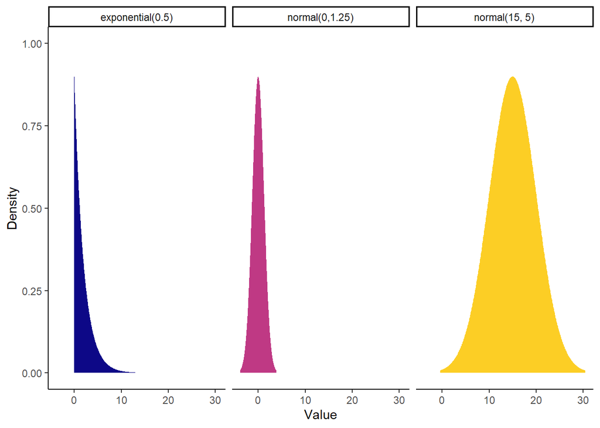

e used R 4.2.2 and several packages including brms, bayestestR, tidybayes, see, emmeans, patchwork, and tidyverse to analyze and visualize the data. Markov Chain Monte Carlo simulations were run with 4000 samples to generate posterior distributions.

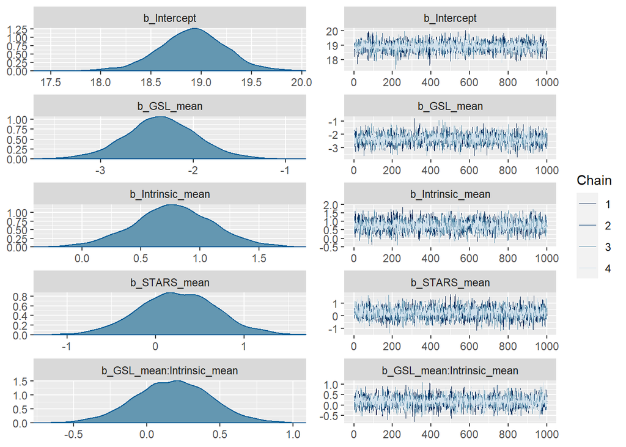

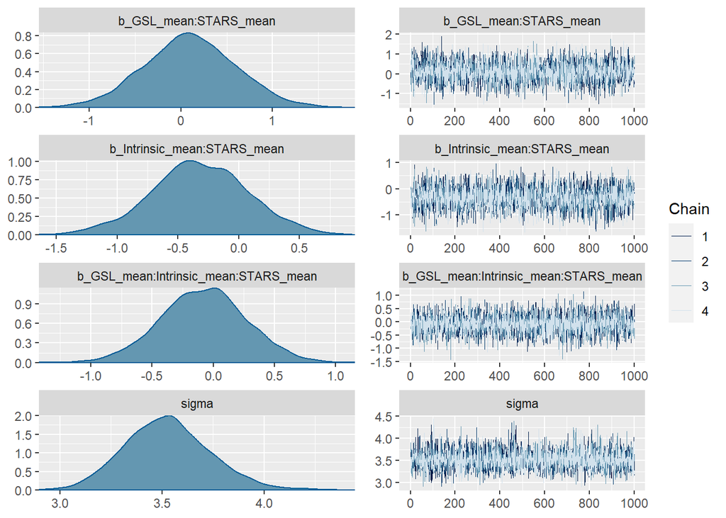

```r
plot(Dunn_fit1)
```

The hat values were all equal to 1, the ESS values were larger than 1000, and the chain visualization showed no indication of getting stuck at a single value, indicating that the model converged well. Furthermore, the plot below demonstrates that the model was able to capture the data pattern.

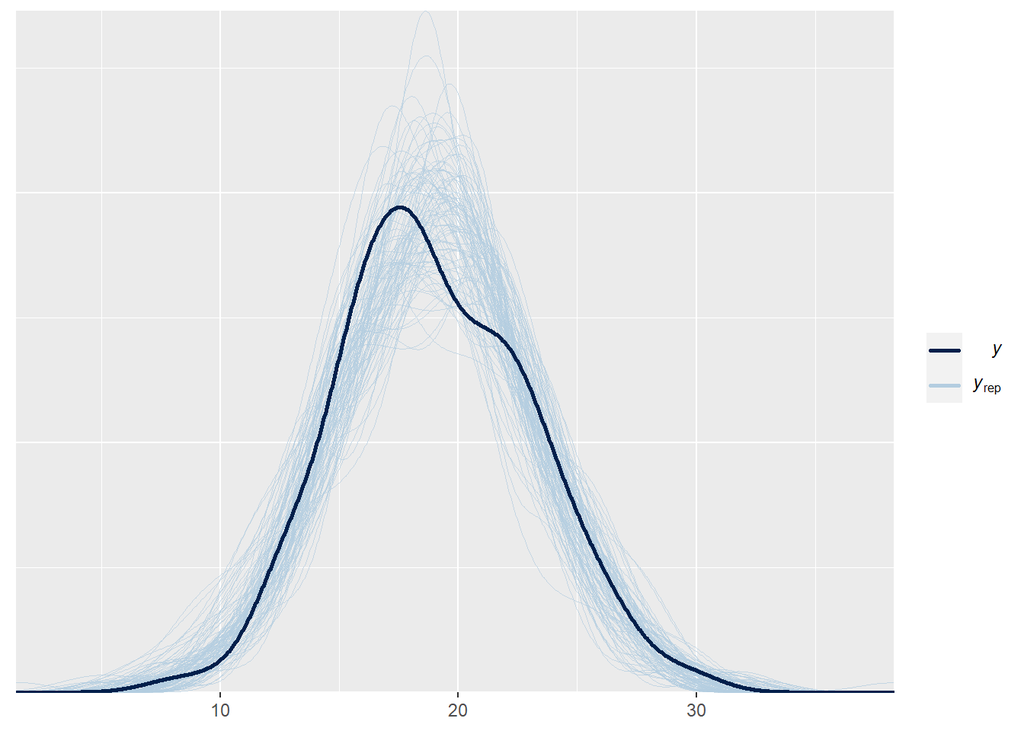

```r
pp_check(Dunn_fit1,
         ndraws = 100)
```

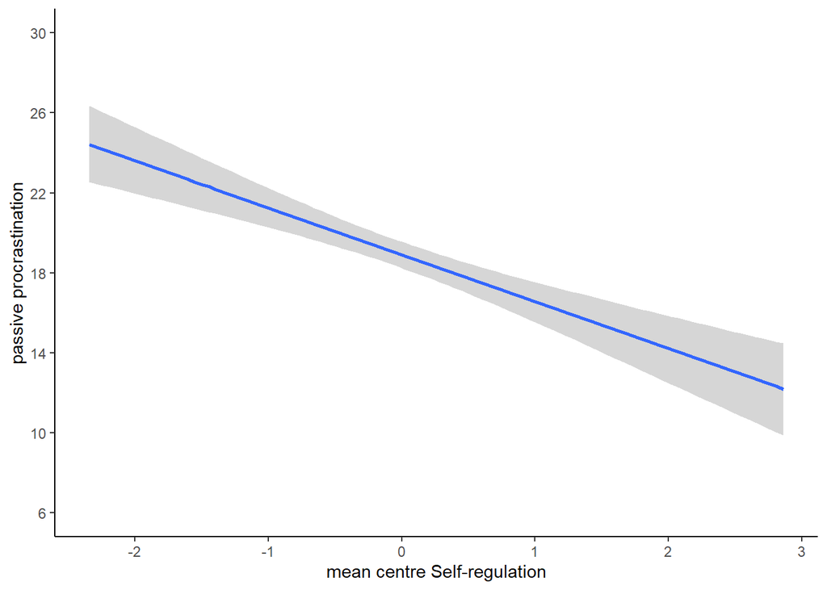

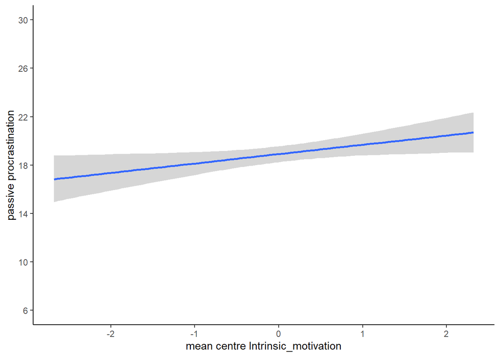

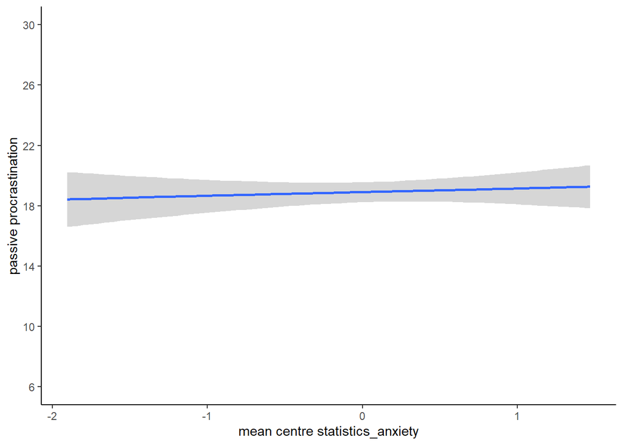

In addition, we investigated the sensitivity of the model to the removal of interactions and the use of different priors. The table below shows the R-square estimate with and without interactions.

|  | R2 Estimate | Estimated Error | Lower 95% HDI | Upper 95% HDI |
| --- | --- | --- | --- | --- |
| Model with interaction | 0.25 | 0.05 | 0.15 | 0.35 |
| Model without interaction | 0.23 | 0.05 | 0.13 | 0.33 |

Interestingly, despite our previous finding suggesting that interactions have no effect on passive procrastination, we observed that the model with interactions included had a slightly higher R-square than the model without interactions, although the difference was not substantial.

We then focused on how the model was sensitive to the prior. The summary order was for the current prior model and the default prior model. By comparing the short posterior summary, we observed that the prior we chose had very little influence on the final result. This suggests that our results are robust to these two choices of prior, and my prior choice is not too restrictive for this question.

```
## Summary of Posterior Distribution
##
## Parameter                          | Median |         95% CI |     pd |          ROPE | % in ROPE |  Rhat |     ESS
## -------------------------------------------------------------------------------------------------------------------
## (Intercept)                        |  18.92 | [18.24, 19.56] |   100% | [-0.10, 0.10] |        0% | 1.000 | 6481.00
## GSL_mean                           |  -2.35 | [-3.12, -1.57] |   100% | [-0.10, 0.10] |        0% | 1.000 | 4532.00
## Intrinsic_mean                     |   0.77 | [ 0.11,  1.43] | 98.72% | [-0.10, 0.10] |        0% | 1.000 | 4787.00
## STARS_mean                         |   0.24 | [-0.63,  1.14] | 71.33% | [-0.10, 0.10] |    16.29% | 1.000 | 4903.00
## GSL_mean:Intrinsic_mean            |   0.18 | [-0.34,  0.70] | 75.75% | [-0.10, 0.10] |    25.92% | 1.000 | 5636.00
## GSL_mean:STARS_mean                |   0.10 | [-0.88,  1.08] | 57.80% | [-0.10, 0.10] |    17.39% | 0.999 | 4373.00
## Intrinsic_mean:STARS_mean          |  -0.33 | [-1.13,  0.46] | 79.42% | [-0.10, 0.10] |    14.87% | 1.000 | 4111.00
## GSL_mean:Intrinsic_mean:STARS_mean |  -0.08 | [-0.77,  0.60] | 58.40% | [-0.10, 0.10] |    23.89% | 0.999 | 5341.00
```

```
## Summary of Posterior Distribution
##
## Parameter                          | Median |         95% CI |     pd |          ROPE | % in ROPE |  Rhat |     ESS
## -------------------------------------------------------------------------------------------------------------------
## (Intercept)                        |  18.90 | [18.23, 19.56] |   100% | [-0.10, 0.10] |        0% | 1.000 | 5945.00
## GSL_mean                           |  -2.65 | [-3.44, -1.85] |   100% | [-0.10, 0.10] |        0% | 1.001 | 4201.00
## Intrinsic_mean                     |   0.97 | [ 0.27,  1.64] | 99.50% | [-0.10, 0.10] |        0% | 1.001 | 4027.00
## STARS_mean                         |   0.25 | [-0.67,  1.21] | 70.67% | [-0.10, 0.10] |    14.63% | 1.001 | 3963.00
## GSL_mean:Intrinsic_mean            |   0.21 | [-0.33,  0.72] | 78.15% | [-0.10, 0.10] |    24.55% | 1.000 | 5548.00
## GSL_mean:STARS_mean                |   0.27 | [-0.84,  1.35] | 68.70% | [-0.10, 0.10] |    13.11% | 1.000 | 3795.00
## Intrinsic_mean:STARS_mean          |  -0.39 | [-1.28,  0.45] | 81.90% | [-0.10, 0.10] |    13.47% | 1.001 | 3532.00
## GSL_mean:Intrinsic_mean:STARS_mean |  -0.09 | [-0.82,  0.65] | 59.52% | [-0.10, 0.10] |    21.95% | 1.002 | 3583.00
```

Finally, I have uploaded all the models and data that I used to GitHub (link provided at the beginning). Please feel free to download and re-run them.

# Reference

Bürkner, P.-C., & Vuorre, M. (2019). Ordinal regression models in psychology: A tutorial. *Advances in Methods and Practices in Psychological Science*, *2*(1), 77–101. https://doi.org/10.1177/2515245918823199

Dunn, K. (2014). Why wait? The influence of academic self-regulation, intrinsic motivation, and statistics anxiety on procrastination in online statistics. *Innovative Higher Education*, *39*, 33–44.

Ghaderi-Kangavari, A., Parand, K., Ebrahimpour, R., Nunez, M. D., & Rad, J. A. (2021). How spatial attention affects the decision process: Looking through the lens of bayesian hierarchical diffusion model & EEG analysis. *bioRxiv*, 2021–2005.

Jones, G. E., & Kavanagh, M. J. (1996). An experimental examination of the effects of individual and situational factors on unethical behavioral intentions in the workplace. *Journal of Business Ethics*, *15*, 511–523.

Kruschke, J. K. (2021). Bayesian analysis reporting guidelines. *Nature Human Behaviour*, *5*(10), 1282–1291.

Wagenmakers, E.-J., Wetzels, R., Borsboom, D., & Van Der Maas, H. L. (2011). *Why psychologists must change the way they analyze their data: The case of psi: Comment on bem (2011).*